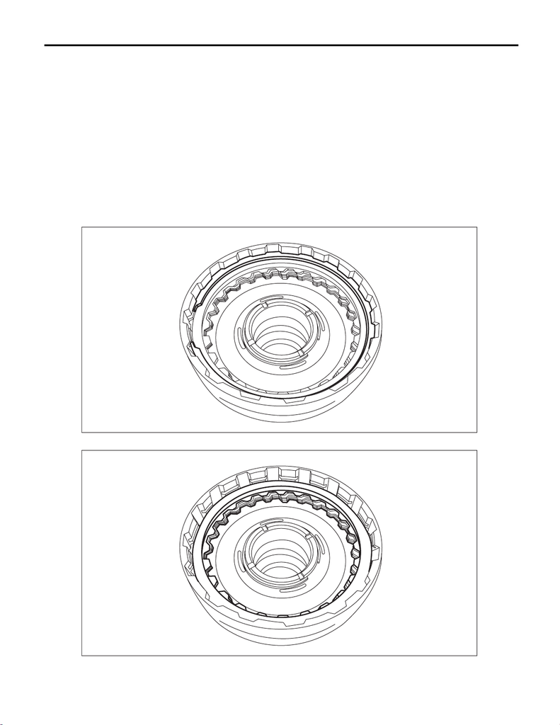

CVT(TR690)-310

Front Reduction Driven Gear

CONTINUOUSLY VARIABLE TRANSMISSION

49.Front Reduction Driven Gear

A: REMOVAL

NOTE:

For removal of front reduction driven gear, refer to the “Front Reduction Drive Gear”. <Ref. to CVT(TR690)-

302, REMOVAL, Front Reduction Drive Gear.>

B: INSTALLATION

NOTE:

For installation of front reduction driven gear, refer to the “Front Reduction Drive Gear”. <Ref. to

CVT(TR690)-303, INSTALLATION, Front Reduction Drive Gear.>

C: DISASSEMBLY

1) Remove the front reduction driven shaft from the front reduction driven gear.

2) Remove the snap ring.

3) Remove the retaining plate, drive plate, driven plate and dish plate.

AT-06558

AT-05436

15WRX_STI_US_EN.book 310 ページ ２０１５年２月１３日 金曜日 午前１１時２０分

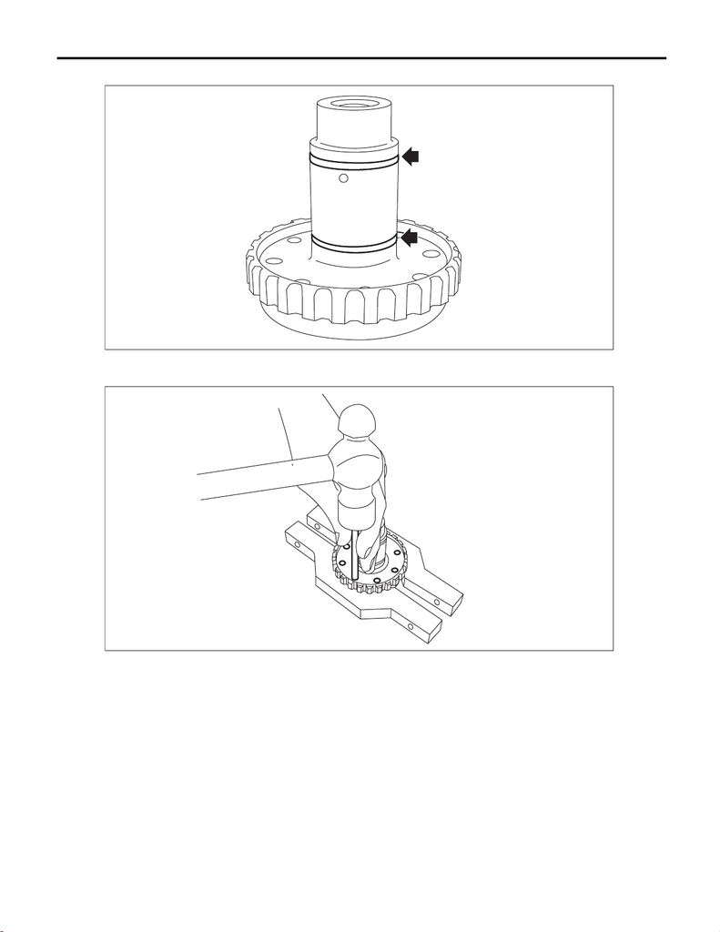

CVT(TR690)-311

Front Reduction Driven Gear

CONTINUOUSLY VARIABLE TRANSMISSION

4) Remove the seal ring from front reduction driven shaft.

5) Remove the ball bearing, while tapping the entire circumference around the ball bearing outer race a little

at a time through the front reduction driven shaft hole using the round bar with diameter of 7 mm (0.28 in).

D: ASSEMBLY

1) Place the dish plate, driven plate, drive plate and retaining plate neatly in this order on surface table.

NOTE:

Make sure of the direction of dish plate.

2) Set the dial gauge to retaining plate, and read its scale.

NOTE:

The value, which is read in the gauge at this time, is zero point.

3) Scale and record the weight “Z” of a flat board which will be put on retaining plate.

NOTE:

• Use a stiff board which does not bend against load as a flat board to be put on retaining plate.

• Use a flat board weighing less than 130 N (13.3 kgf, 29.2 lb).

AT-05437

AT-05678

15WRX_STI_US_EN.book 311 ページ ２０１５年２月１３日 金曜日 午前１１時２０分

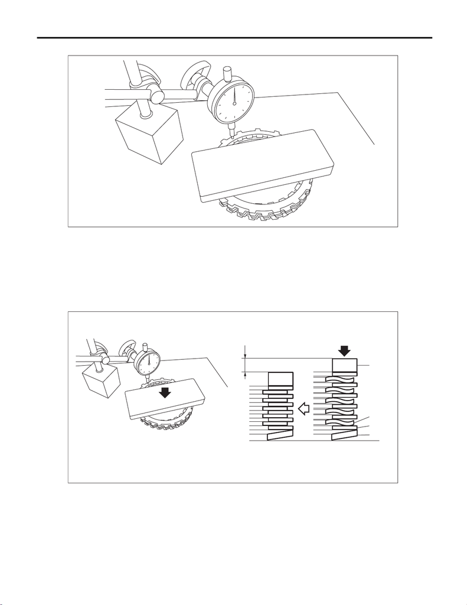

CVT(TR690)-312

Front Reduction Driven Gear

CONTINUOUSLY VARIABLE TRANSMISSION

4) Put the flat board on retaining plate.

5) Using the following formula, calculate load “N”, a force of pressing with push/pull gauge.

N = 130N (13.3 kgf, 29.2 kg) – Z

130 N (13.3 kgf, 29.2 lb) : Load applied to clutch plate

Z: Flat board weight

6) Press the center of retaining plate by applying a force of “N” using push/pull gauge, and then measure and

record the compression amount “A”.

NOTE:

Measure at four points with a 90° interval and calculate the average.

(A) Drive plate

(B) Driven plate

(C) Retaining plate

(D) Dish plate

AT-05234

AT-05587

(A)

(C)

(B)

A

(D)

15WRX_STI_US_EN.book 312 ページ ２０１５年２月１３日 金曜日 午前１１時２０分

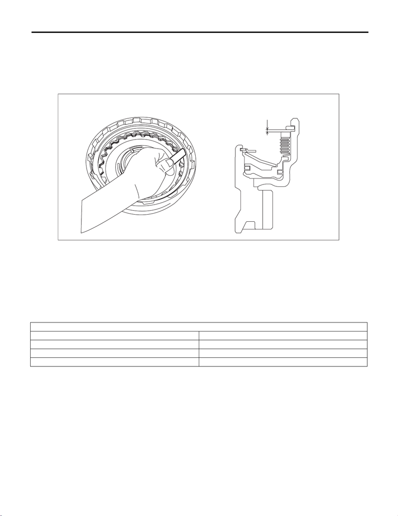

CVT(TR690)-313

Front Reduction Driven Gear

CONTINUOUSLY VARIABLE TRANSMISSION

7) Install the dish plate, driven plate, drive plate, retaining plate and snap ring.

NOTE:

Make sure of the direction of dish plate.

8) Measure and record the clearance “B” between the retaining plate and snap ring.

NOTE:

Before measuring, press down the whole circumference of retaining plate using your finger.

9) Piston stroke calculation

Calculate with A and B dimensions recorded before.

If out of standard, replace with a new drive plate and adjust it within standard.

S mm (in) = A + B

S: Piston stroke

A: Compression amount of drive plate and dish plate

B: Clearance between retaining plate and snap ring

Specification:

2.4 — 2.8 mm (0.094 — 0.11 in)

Retaining plate

Part No. Thickness mm (in)

31667AB430 3.1 (0.122)

31667AB440 3.3 (0.130)

31667AB450 3.5 (0.138)

AT-06559

B

15WRX_STI_US_EN.book 313 ページ ２０１５年２月１３日 金曜日 午前１１時２０分

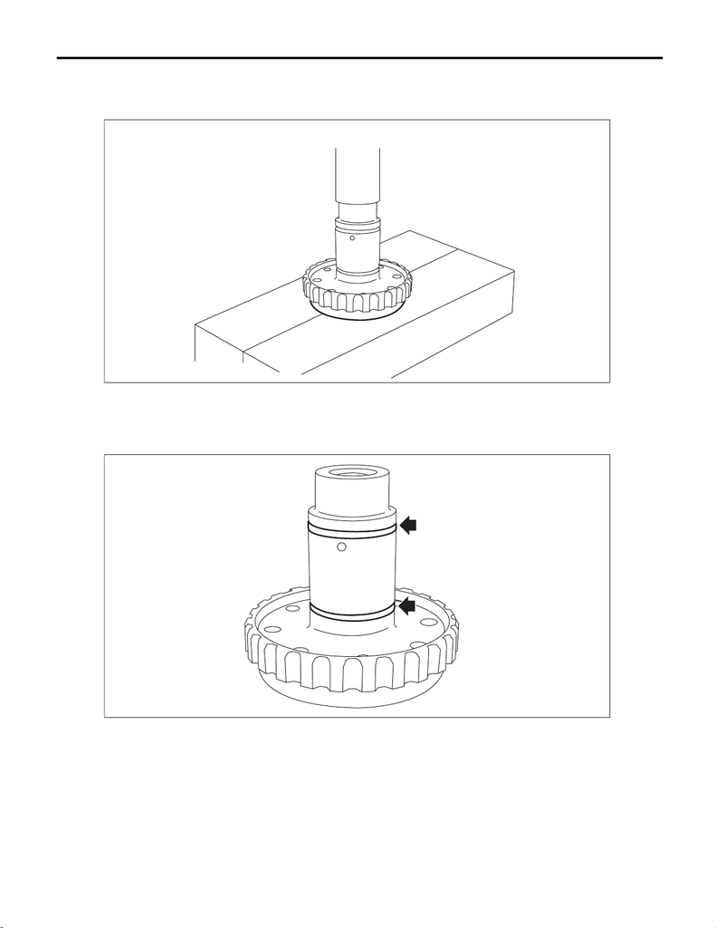

CVT(TR690)-314

Front Reduction Driven Gear

CONTINUOUSLY VARIABLE TRANSMISSION

10) Press-fit the ball bearing into front driven shaft.

NOTE:

Use a new ball bearing.

11) Install the seal ring to the front driven shaft.

NOTE:

• Install a new seal ring.

• Apply CVTF to the seal rings.

AT-05440

AT-05437

15WRX_STI_US_EN.book 314 ページ ２０１５年２月１３日 金曜日 午前１１時２０分

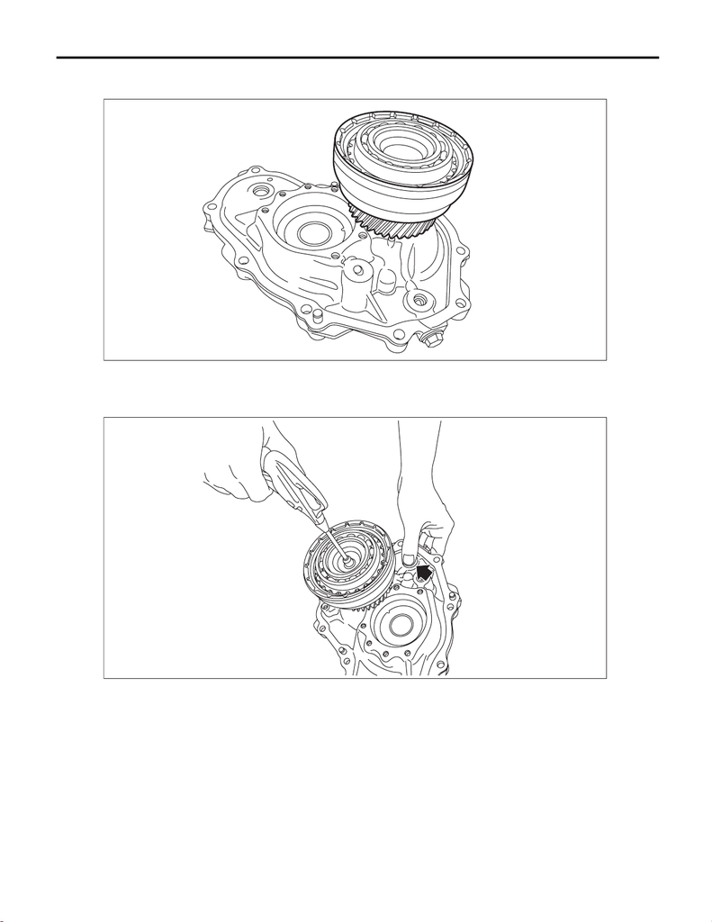

CVT(TR690)-315

Front Reduction Driven Gear

CONTINUOUSLY VARIABLE TRANSMISSION

12) Install the front reduction driven shaft to the front reduction driven gear.

13) Install the front reduction driven gear assembly to converter case cover.

14) Apply compressed air intermittently to check the piston operation.

NOTE:

Hold the arrowed area with a finger.

E: INSPECTION

• Check the drive plate for wear and damage.

• Check the driven plate for discoloration (burnt color).

• Check for worn snap ring, fatigue or damaged return spring or deformed piston retainer.

• Replace if its tooth surfaces are broken, damaged or excessively worn.

• Check the bearing for seizure or wear.

• Apply CVTF to bearing and rotate the bearing to check for noise or dragging etc.

AT-05445

AT-05446

15WRX_STI_US_EN.book 315 ページ ２０１５年２月１３日 金曜日 午前１１時２０分

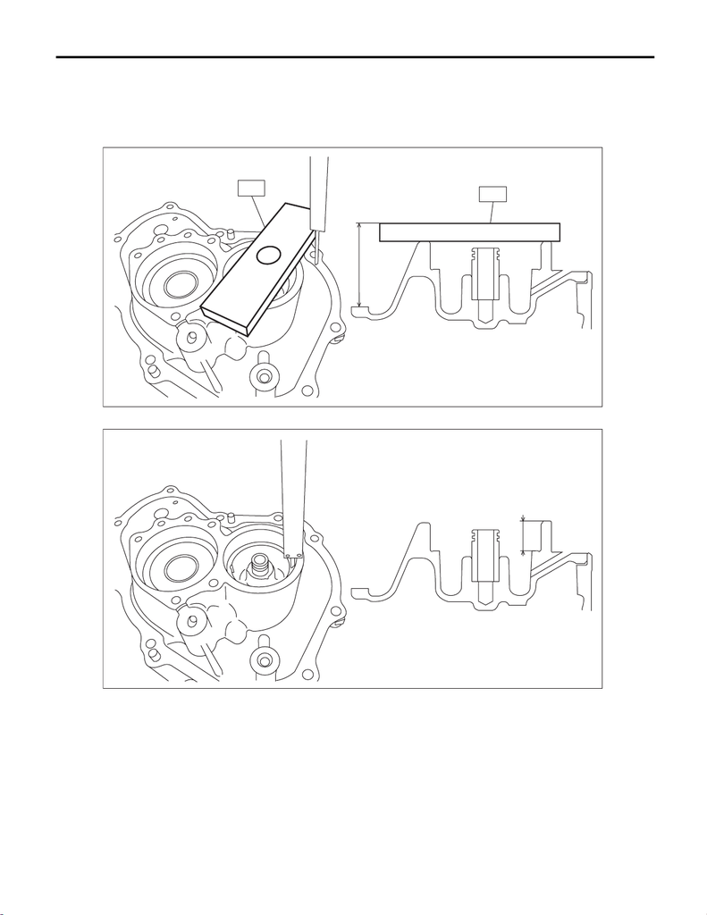

CVT(TR690)-316

Front Reduction Driven Gear

CONTINUOUSLY VARIABLE TRANSMISSION

F: ADJUSTMENT

1) If the ball bearing is attached, remove the bearing and shims. <Ref. to CVT(TR690)-292, REMOVAL, Con-

verter Case Cover.>

2) Using the ST, measure height “A” from the ST upper face to the mating surface of the case.

ST 398643600 GAUGE

3) Measure depth “B” from the converter case cover upper face to the bearing catch surface.

AT-05442

A

ST

ST

AT-05441

B

15WRX_STI_US_EN.book 316 ページ ２０１５年２月１３日 金曜日 午前１１時２０分

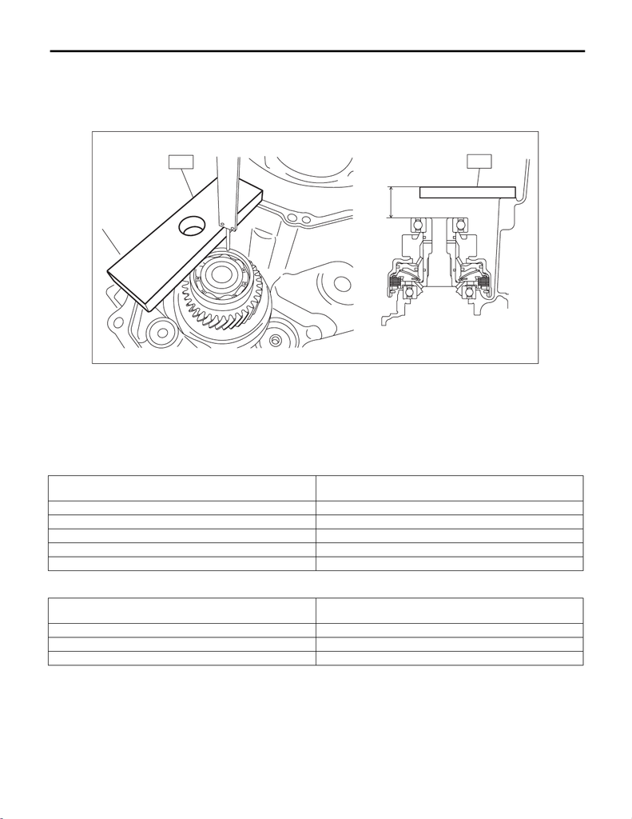

CVT(TR690)-317

Front Reduction Driven Gear

CONTINUOUSLY VARIABLE TRANSMISSION

4) Install the ball bearing to the reduction driven gear.

NOTE:

Use a new ball bearing.

5) Measure depth “C” from the ST upper face to the bearing end face using the ST.

ST 398643600 GAUGE

6) Calculate clearance “T” using the following formula.

Formula: T mm = (C – 15) – ((A – 15) – B)

[T in = (C – 0.591) – ((A – 0.591) – B)]

T: Clearance

A: Height from the ST upper face to the converter case mating surface

B: Depth from the converter case cover upper face to the bearing catch surface

C: Depth from the ST upper face to the bearing end face

15 mm (0.591 in): Thickness of ST

7) Select one to two shims so that the total thickness meets the value obtained from above.

Clearance “T”

mm (in)

Thickness of shim

mm (in)

0.470 — 0.569 (0.019 — 0.021) 0.4 (0.016)

0.570 — 0.669 (0.022 — 0.025) 0.5 (0.020)

0.670 — 0.769 (0.026 — 0.029) 0.6 (0.024)

0.770 — 0.869 (0.030 — 0.033) 0.7 (0.028)

0.870 — 0.980 (0.034 — 0.039) 0.8 (0.031)

Part No.

Thickness of shim

mm (in)

31288AA130 0.2 (0.008)

31288AA140 0.3 (0.012)

31288AA150 0.5 (0.020)

AT-05443

ST

ST

C

15WRX_STI_US_EN.book 317 ページ ２０１５年２月１３日 金曜日 午前１１時２０分